# Statistical Modeling

## Probability

In probability theory, we explore the likelihood of events occurring. Events are defined in terms of sets, and the relationships between these sets can be used to calculate probabilities.

- **Complement Rule:**

## Distributions

Distributions are functions that describe the probabilities of outcomes in a statistical experiment. There are two types of distributions: the **Probability Density Function (PDF)** and the **Cumulative Distribution Function (CDF)**.

**PDF vs CDF:**

- **PDF (Probability Density Function):** The probability that a continuous random variable takes a value exactly equal to x is essentially 0; instead, the PDF provides the density of the probability at any point. In the discrete case, this is simply the probability of $X = x$
- **CDF (Cumulative Distribution Function):** The CDF represents the probability that a random variable takes a value less than or equal to $x$.

CDF of X: $F(x) = P(X \le x)$

PDF of X: $f(x) = P(X = x)$ ONLY IN DISCRETE CASE!

Example: You can use both the PDF and CDF of the **Normal Distribution** (a common continuous distribution) to model data that follows a bell-shaped curve.

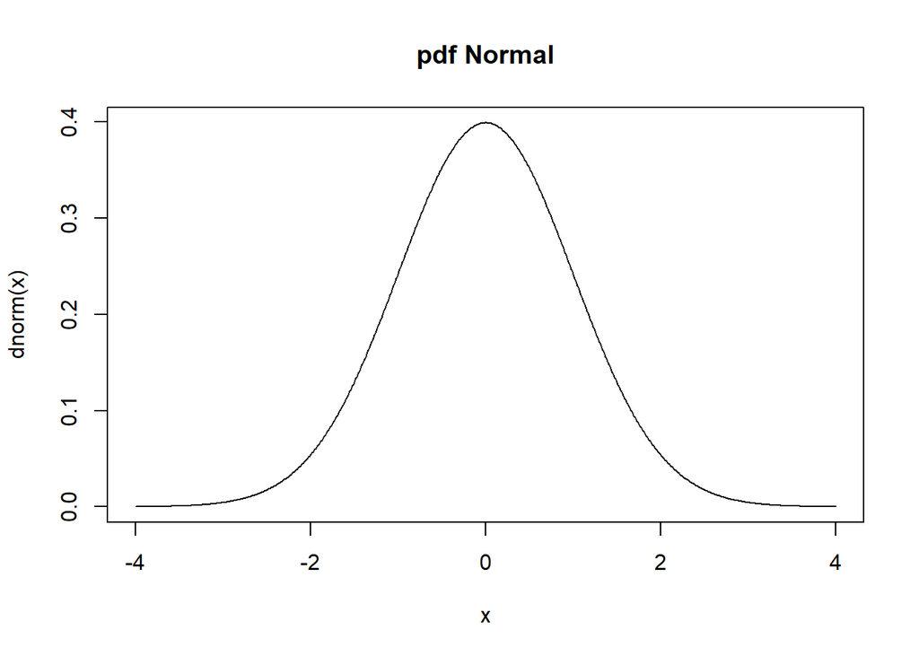

```r
library(tidyverse)
x <- seq(-4,4,0.01)
plot(x, dnorm(x), type = "l", main = "pdf Normal")
```

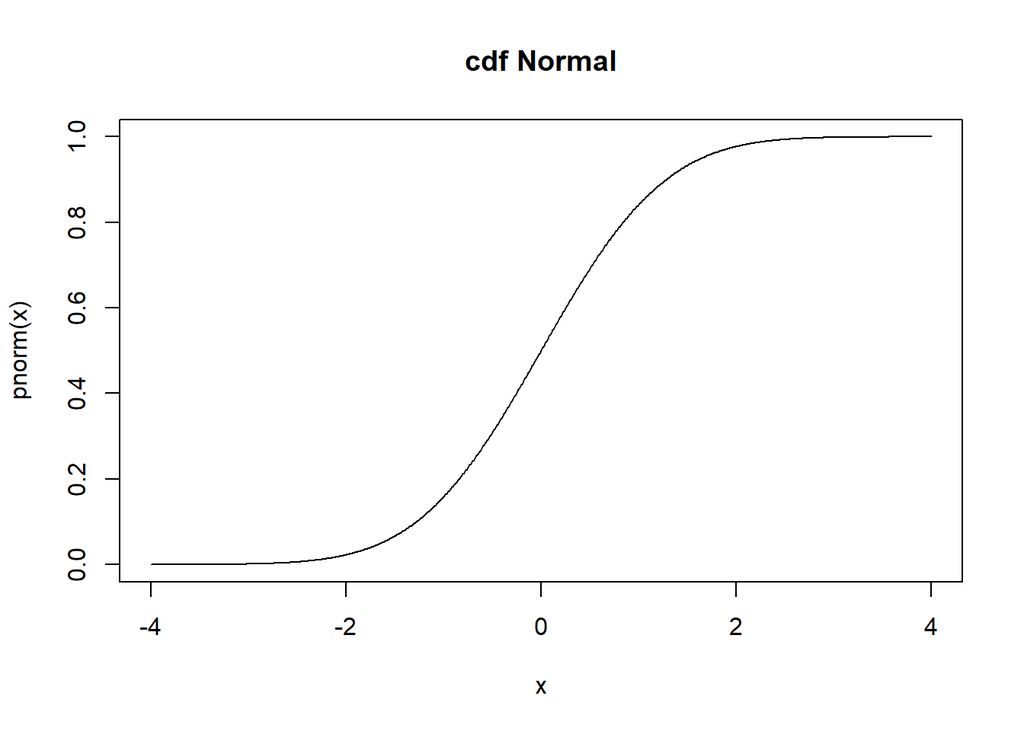

```r
plot(x, pnorm(x), type = "l", main = "cdf Normal")
```

Here, you plot the PDF and CDF of a Normal distribution with mean 0 and standard deviation 1.

Similarly, for a **Binomial Distribution** (a discrete distribution), you can visualize the PDF and CDF, which tells you the probability of getting $x$ successes in $n$ trials.

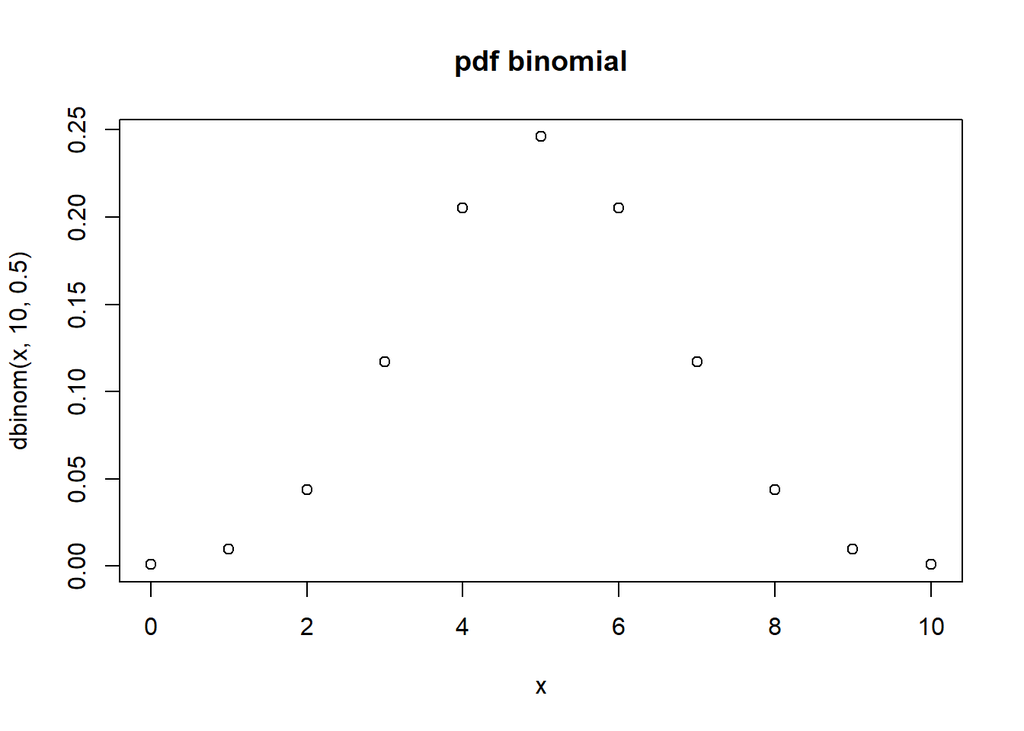

```r
x <- c(0:10)
plot(x, dbinom(x,10,0.5),  main = "pdf binomial")
```

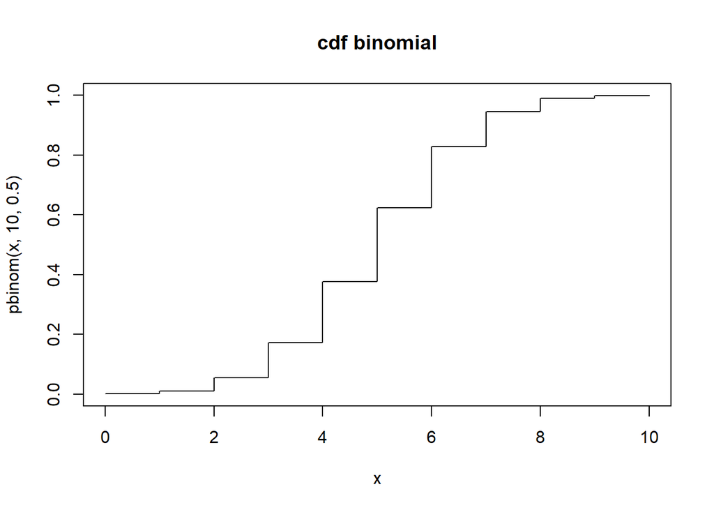

```r
x <- seq(0,10,0.01)
plot(x, pbinom(x,10,0.5), type = "l",  main = "cdf binomial")
```

#### Applications

- Let X ~ normal(0,1) - Let Y ~ binomial(10,0.5) - Let B ~ binomial(1,0.5) - Let Z | B ~ normal(B, 1) - Find probability that X > 1 give X > 0. - That is find P(X > 1 | X > 0). - Find P(Y = 5 AND -1 < X < 1) - Find P(Z > 0)

```r
# Set the random seed for reproducibility
set.seed(2024)

# 1. Find P(X > 1 | X > 0) where X ~ normal(0,1)
# Generate a large number of samples from N(0,1) to approximate the probability
n <- 1e6  # Number of simulations
X <- rnorm(n, mean = 0, sd = 1)

# Calculate the conditional probability P(X > 1 | X > 0)
p1 <- sum(X > 1 & X > 0) / sum(X > 0)
p1
```

```
[1] 0.3170498
```

```r
# Output: Approximate probability

# 2. Find P(Y = 5 AND -1 < X < 1)
# where Y ~ Binomial(10, 0.5) and X ~ Normal(0,1)

# Generate samples for Y from a Binomial(10, 0.5)
Y <- rbinom(n, size = 10, prob = 0.5)

# Calculate the joint probability P(Y = 5 AND -1 < X < 1)
p5 <- sum(Y == 5 & X > -1 & X < 1) / n
p5
```

```
[1] 0.167404
```

```r
# Output: Approximate probability

# 3. Find P(Z > 0) where Z | B ~ Normal(B, 1) and B ~ Binomial(1, 0.5)
# Generate samples for B from a Binomial(1, 0.5)
B <- rbinom(n, size = 1, prob = 0.5)

# Generate Z conditional on B, so Z ~ N(B, 1)
Z <- rnorm(n, mean = B, sd = 1)

# Calculate the probability P(Z > 0)
p0 <- mean(Z > 0)
p0
```

```
[1] 0.670252
```

```r
# Output: Approximate probability
```

- $P(X > 1 | X > 0)$: We use conditional probability by counting instances where $X>1$ within the subset of samples where $X>0$.
- $P(Y = 5 \text{ AND } -1 < X < 1)$: We find the probability that both $Y = 5$ (a specific outcome of a binomial random variable) and X falls in the interval (−1,1).
- $P(Z > 0)$: Here, Z is generated based on a binary random variable B that shifts the mean of Z to either 0 or 1. We then compute the probability that Z is greater than 0.

## Inference

Statistical inference allows us to draw conclusions about a population based on a sample. The key ideas here include point estimates, confidence intervals, and hypothesis testing.

#### **Point Estimates:**

A **point estimate** provides a single best guess for the value of an unknown parameter (e.g., population mean). Common point estimates include the sample mean or sample median.

#### **Confidence Intervals:**

A **confidence interval (CI)** gives a range of plausible values for a parameter, along with a level of confidence (e.g., 95% CI means we are 95% confident the true parameter lies within this range).

#### **Hypothesis Testing:**

Hypothesis testing is a method for testing a claim about a population based on sample data.

- **Permutation Testing:** A non-parametric approach to hypothesis testing, where we compare the observed test statistic to a distribution of test statistics generated by resampling.
- **t-test:** A test for comparing the means of two groups, assuming the data is normally distributed.
- **Chi-squared** Test: Used to test the association between categorical variables.
- **p-values:** The p-value tells you the probability of observing data as extreme as what was observed, assuming the null hypothesis is true. A smaller p-value indicates stronger evidence against the null hypothesis.

### **Simulation Studies**

Simulation studies help us explore the behavior of statistical methods, such as hypothesis testing, under various conditions. For example, the following simulation code generates random samples from a normal distribution and calculates the t-statistic for each sample:

Lets do some simulations about point estimates and look at their properties - sample mean vs sample median

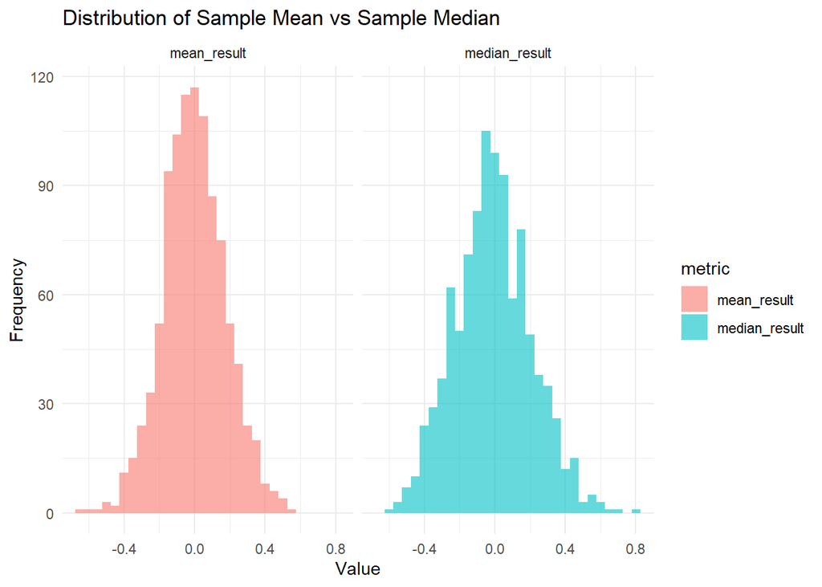

```r
nsim <- 1000  # Number of simulations
sample_size <- 30  # Sample size for each sample

# Generate a tibble with mean and median from each simulation
sim_data <- tibble(
  sim = 1:nsim,
  mean_result = map_dbl(1:nsim, ~ mean(rnorm(sample_size))),
  median_result = map_dbl(1:nsim, ~ median(rnorm(sample_size)))
)

# Reshape data for easy plotting
sim_data_long <- sim_data %>%
  pivot_longer(cols = c(mean_result, median_result), names_to = "metric", values_to = "value")

# Plot distributions of sample mean and sample median
ggplot(sim_data_long, aes(x = value, fill = metric)) +
  geom_histogram(alpha = 0.6, position = "identity", bins = 30) +
  facet_wrap(~ metric) +
  labs(title = "Distribution of Sample Mean vs Sample Median", x = "Value", y = "Frequency") +
  theme_minimal()
```

Let’s look at confidence interval coverage for a proportion.

```r
true_p <- 0.5  # True population proportion
sample_size <- 100
nsim <- 1000  # Number of simulations

# Simulate confidence intervals
ci_data <- tibble(
  sim = 1:nsim,
  sample_prop = map_dbl(1:nsim, ~ mean(rbinom(sample_size, 1, true_p))),
  se = map_dbl(1:nsim, ~ sqrt((mean(rbinom(sample_size, 1, true_p)) * (1 - mean(rbinom(sample_size, 1, true_p))) / sample_size))),
  lower_ci = sample_prop - 1.96 * se,
  upper_ci = sample_prop + 1.96 * se
) %>%
  mutate(contains_true_p = (lower_ci <= true_p & upper_ci >= true_p))

# Coverage proportion
mean(ci_data$contains_true_p)
```

```
[1] 0.948
```

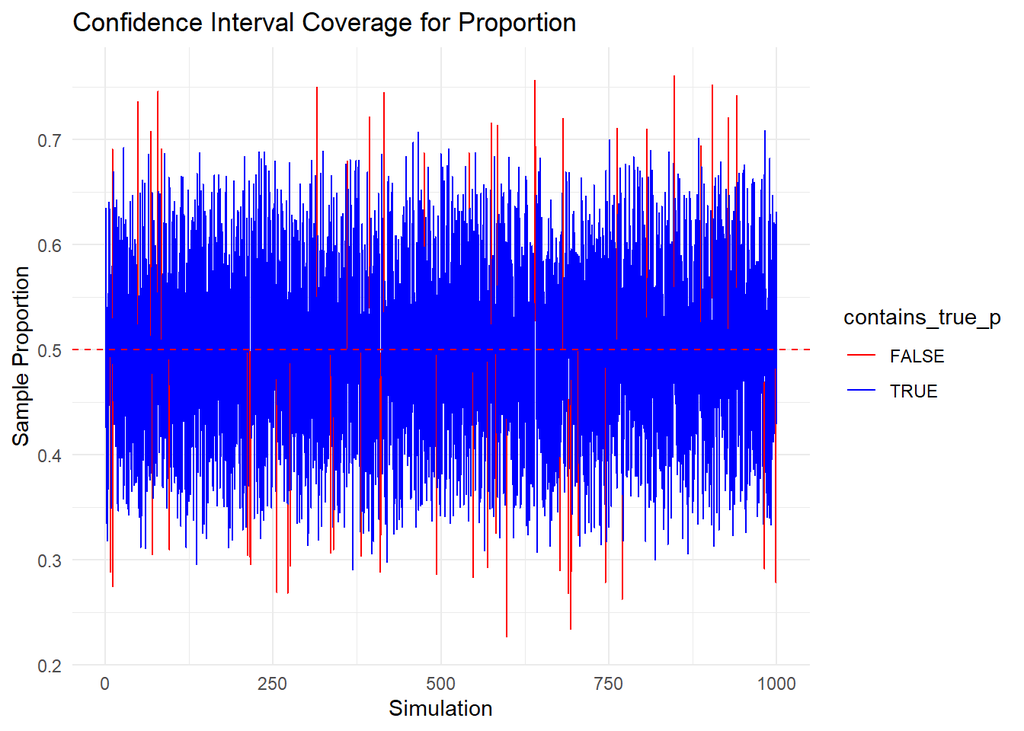

```r
# Plot confidence intervals, with intervals containing the true p in a different color
ggplot(ci_data, aes(x = sim, y = sample_prop)) +
  geom_errorbar(aes(ymin = lower_ci, ymax = upper_ci, color = contains_true_p), width = 0.2) +
  geom_hline(yintercept = true_p, linetype = "dashed", color = "red") +
  scale_color_manual(values = c("red", "blue")) +
  labs(title = "Confidence Interval Coverage for Proportion", x = "Simulation", y = "Sample Proportion") +
  theme_minimal()
```

Let’s do hypothesis testing “by hand”. We’ll do a t-test by hand.

```r
mu0 <- 50  # Null hypothesis mean
sample_size <- 30
nsim <- 1000
alpha <- 0.05

# Perform hypothesis test
t_test_data <- tibble(
  sim = 1:nsim,
  sample_mean = map_dbl(1:nsim, ~ mean(rnorm(sample_size, mean = 52, sd = 5))),
  sample_sd = map_dbl(1:nsim, ~ sd(rnorm(sample_size, mean = 52, sd = 5))),
  t_stat = (sample_mean - mu0) / (sample_sd / sqrt(sample_size)),
  reject_null = abs(t_stat) > qt(1 - alpha / 2, df = sample_size - 1)
)

# Proportion of tests that rejected the null hypothesis
mean(t_test_data$reject_null)
```

```
[1] 0.547
```

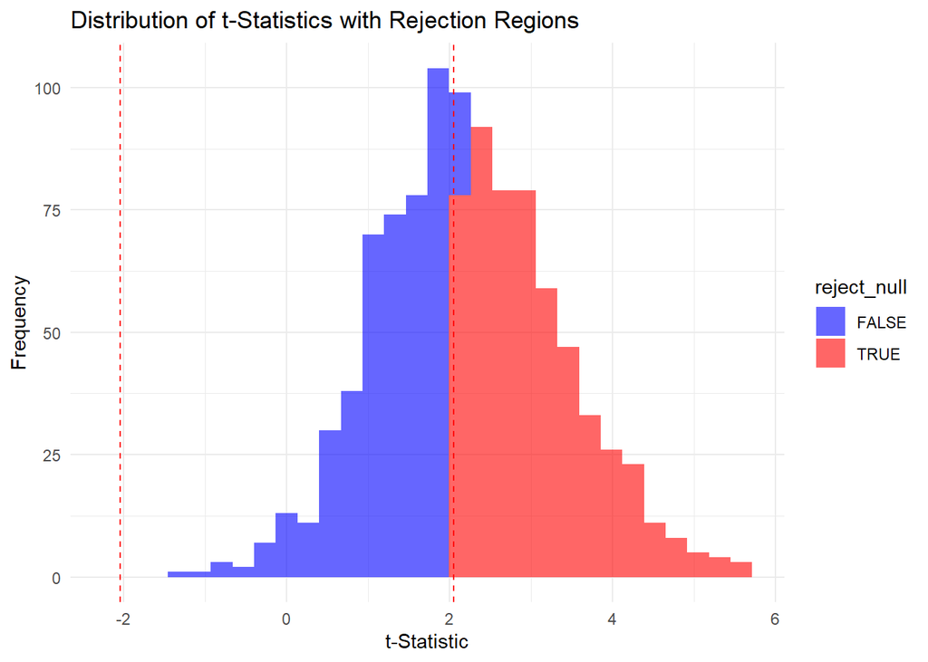

```r
# Plot distribution of t-statistics and critical regions
ggplot(t_test_data, aes(x = t_stat, fill = reject_null)) +
  geom_histogram(bins = 30, alpha = 0.6) +
  geom_vline(xintercept = c(qt(1 - alpha / 2, df = sample_size - 1), -qt(1 - alpha / 2, df = sample_size - 1)), linetype = "dashed", color = "red") +
  labs(title = "Distribution of t-Statistics with Rejection Regions", x = "t-Statistic", y = "Frequency") +
  scale_fill_manual(values = c("blue", "red")) +
  theme_minimal()
```

Let’s do a permutation test

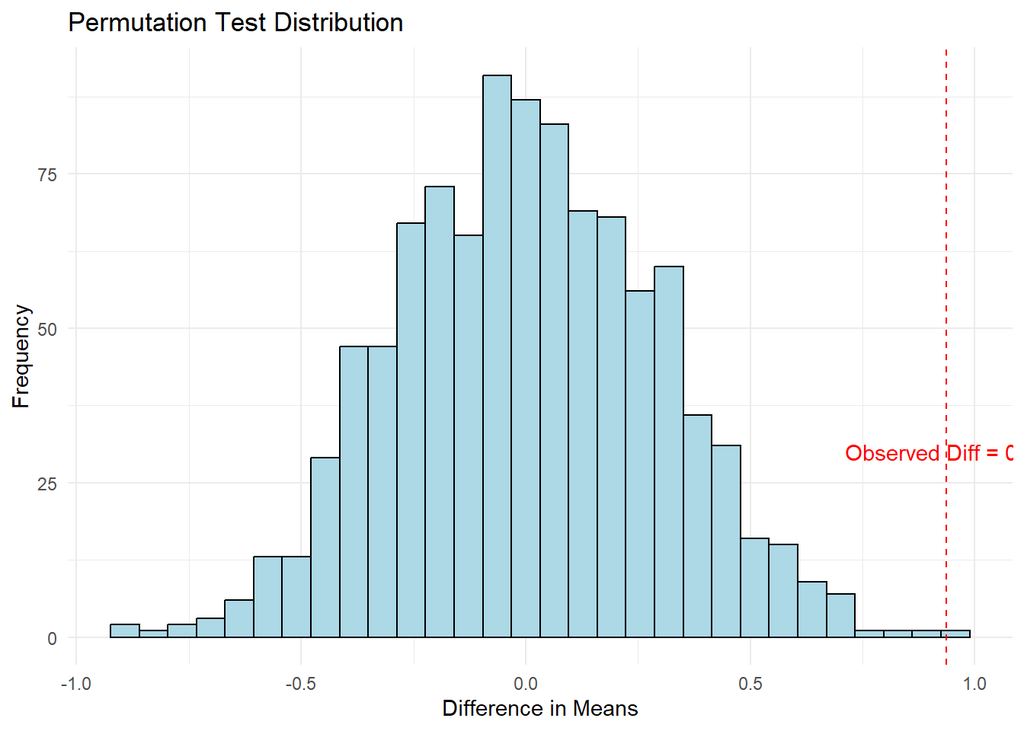

```r
group1 <- rnorm(20, mean = 5, sd = 1)
group2 <- rnorm(20, mean = 5.5, sd = 1)
obs_diff <- mean(group2) - mean(group1)

# Perform permutation test
perm_data <- tibble(
  perm = 1:1000,
  perm_diff = map_dbl(1:1000, ~ {
    permuted <- sample(c(group1, group2))
    mean(permuted[21:40]) - mean(permuted[1:20])
  })
)

# Calculate p-value
p_value <- mean(abs(perm_data$perm_diff) >= abs(obs_diff))

# Plot permutation distribution and observed difference
ggplot(perm_data, aes(x = perm_diff)) +
  geom_histogram(bins = 30, fill = "lightblue", color = "black") +
  geom_vline(xintercept = obs_diff, linetype = "dashed", color = "red") +
  labs(title = "Permutation Test Distribution", x = "Difference in Means", y = "Frequency") +
  annotate("text", x = obs_diff, y = 30, label = paste("Observed Diff =", round(obs_diff, 2)), color = "red") +
  theme_minimal()
```

Let’s talk about p-values.

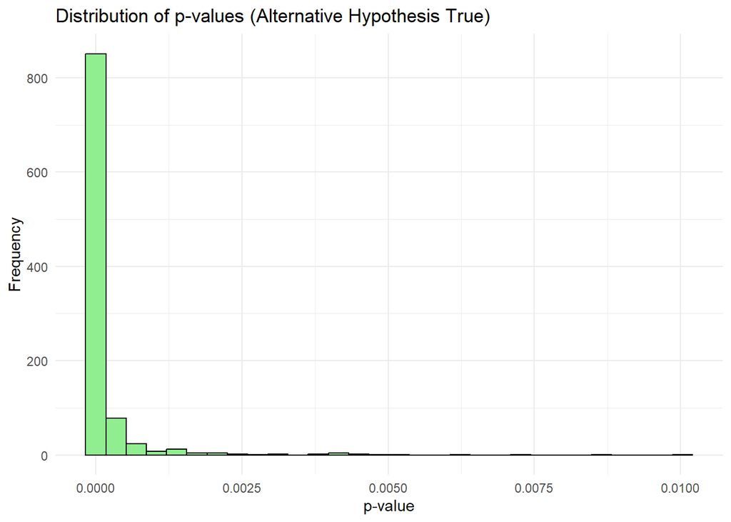

```r
mu0 <- 0
n <- 30
nsim <- 1000

# Simulate p-values
p_values_data <- tibble(
  sim = 1:nsim,
  sample_mean = map_dbl(1:nsim, ~ mean(rnorm(n, mean = 1))),  # Mean set to 1 to test under the alternative
  sample_sd = map_dbl(1:nsim, ~ sd(rnorm(n, mean = 1))),
  t_stat = (sample_mean - mu0) / (sample_sd / sqrt(n)),
  p_value = 2 * (1 - pt(abs(t_stat), df = n - 1))
)

# Plot distribution of p-values
ggplot(p_values_data, aes(x = p_value)) +
  geom_histogram(bins = 30, fill = "lightgreen", color = "black") +
  labs(title = "Distribution of p-values (Alternative Hypothesis True)", x = "p-value", y = "Frequency") +
  theme_minimal()
```